# Project: Investigate a Dataset as a part of Nano Degree Program

### 4. Top 10 actors' gross revenue

> The question ask to know who are in the leaderboard( top 10). The calculation is made based on the revenue the movie earned. Result will be shown in bar and pie graph. Harrison Ford and Tom Cruise first and second respectively.

```python
def calculate_actors_gross_revenue(movies):
    """
        This function takes data, forming dictionary having actors as key and sum of earned revenue as value.
        return this formed dictionary to the caller.
    """
    actors_gross_revenue ={}
    for id,row in movies.iterrows():
        #print(row)
        for key in row.cast:
            if key in actors_gross_revenue:
                #print(actors_gross_revenue[key])
                actors_gross_revenue[key] +=  row.revenue_adj
            else:
                actors_gross_revenue[key] = row.revenue_adj

    return actors_gross_revenue;
```

```python
top_actors_gross_revenue = sorted(calculate_actors_gross_revenue(df_revenue).items(), key=lambda item: item[1], reverse=True)[:10]
```

```python
def list_to_dict(data, label):
    """
        This function uses data as value and label as key for froming a dictionary. At the end return this dictionary.
    """
    top_actors = {label: []}
    index = []

    for item in data:
        top_actors[label].append(item[1])
        index.append(item[0])

    return top_actors, index

top10_actors_revenue, top10_actors_name = list_to_dict(top_actors_gross_revenue, 'actors')
```

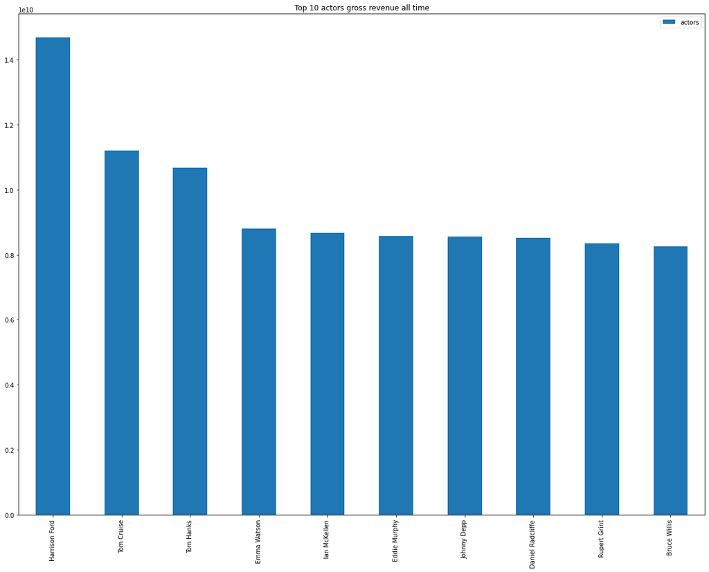

```python
pd.DataFrame(top10_actors_revenue, index=top10_actors_name).plot(kind='bar',title='Top 10 actors gross revenue all time',figsize=(20, 15))
plt.show()
```

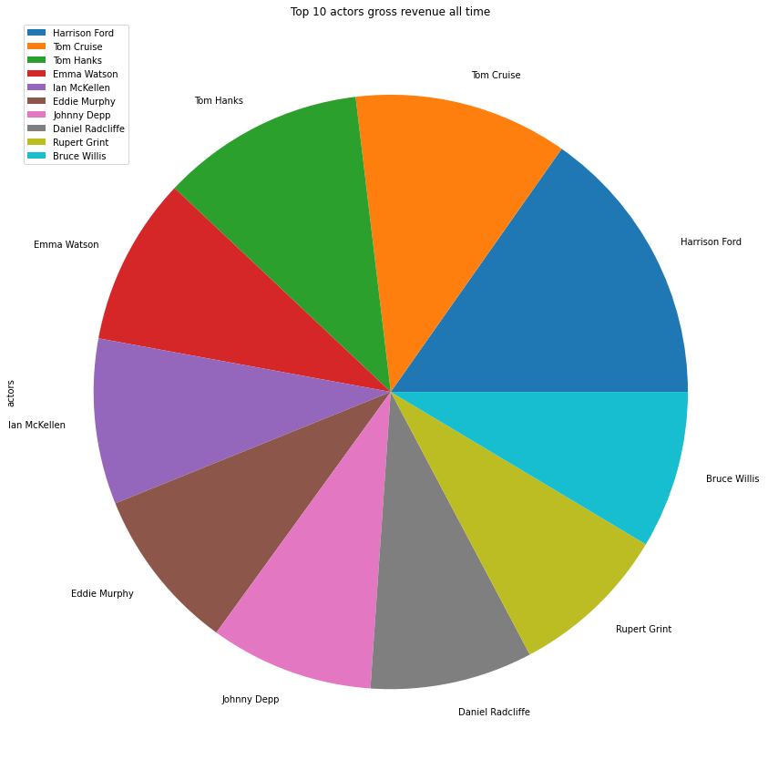

```python
pd.DataFrame(top10_actors_revenue, index=top10_actors_name).plot(kind='pie',y='actors',title='Top 10 actors gross revenue all time',figsize=(20, 15))
plt.show()
```

## Conclusions

> Overall, I got a few significant and meaningful findings and correlation of data. It seems that the movie genre has impacts on most of the findings and observations. It is related to the highest revenue, highest vote, vote count, and popularity. The next one is that the budget and revenue proportion to each other.

## References

1. [Pandas](https://pandas.pydata.org/)
2. [Matplotlib](https://matplotlib.org/)
3. [Stack Overflow](https://stackoverflow.com/)